# My title

two channels. Firstly, because of incomplete markets, low wealth workers search for risky

but easy to find jobs in order to escape unemployment faster. This drives the left half of the

U shape. Secondly, employed workers accumulate assets in order to finance quits to non-

employment, so that they can enjoy temporary breaks from working. This drives the right half

of the U shape. Put together, we find that reasonable parameter values are able to replicate the

U shaped relationship from the data.

The model also generates dynamics for wealth in line with the data. In particular, workers

run down their assets following an *EN* transition, as we saw in the data, and accumulate as-

sets during employment spells. This accumulation is both due to precautionary saving against

involuntary *EN* risk, and to finance voluntary quits. Workers in risky jobs have a higher in-

centive to accumulate precautionary saving, as in Larkin (2019). In his model, this drives a

positive correlation between wealth and *EN* risk. This effect is also present in our model, as

workers in the risky job accumulate assets faster than those in the safe job. However, in our

4This idea mirrors the directed search logic of models such as Herkenhoff et al. (2016) or Eeckhout and Sepahsalari (2021), and others in the literature review below, where non-employed workers with different wealth levels direct their search towards jobs with different wages or levels of productivity.

3

Page 4

model this effect is dominated by the “directed search” effect (that low wealth agents search

for high risk jobs) which drives the negative correlation between wealth and risk in the left half

of the U, as found in the data. The model thus incorporates a “precautionary saving” effect,

“wealth effect”, and “directed search” effect, allowing for rich interactions between wealth and

*EN* risk.

These effects interact to give new insights into the relationship between wealth inequality

and income inequality and income risk. For example, relative to a standard Aiyagari model

where income risk is homogeneous across jobs, the costs of incomplete markets in this model

are more severe because of how income risk correlates with wealth. When income risk is

homogeneous, all agents face the same level of risk, regardless of their wealth. In our model,

and the data, low wealth agents have higher non-employment risk and hence a riskier income

stream. Thus, the agents who have the least access to self-insurance (because they have low

assets) in fact have the greatest need for private insurance because their income risk is high.

In contrast, at the top of the wealth distribution we find that income risk appears high, but

since this is driven by *voluntary* quits to unemployment this is in fact not risk, but rather an

optimising decision. The decline in income from the quit is compensated by foregoing the

cost of working, and hence the welfare cost of the income risk is dampened relative to simply

looking at the income itself. These findings suggest a novel motivation for asset-dependent

unemployment insurance (Rendahl, 2012) in order to help low wealth agents search for safer

jobs.

**Related Literature** Our paper contributes to both the empirical and quantitative literature

on incomplete market models, as well as richer models of labour market frictions and deci-

sions. Aiyagari-Bewley-Hugget-Imrohoro˘glu incomplete market models have been extended

to include richer income processes as data and modelling power improve. A large literature

extends the income process to be more realistic, for example incorporating richer income data

from papers such as Guvenen et al. (2021), but while maintaining that the income process is

exogenous. Our focus is instead within the literature that micro-founds the income process in

the search tradition.

On the empirical side, a small but growing literature has documented the effect of wealth

on labour market transitions and hence the income process. An important finding, repeated

across several papers, is that non-employed workers with higher wealth spend longer in un-

employment, i.e. have lower *EU* rates. This is shown by Bloemen and Stancanelli (2001), Algan

et al. (2003), Chetty (2008), Herkenhoff et al. (2016), and Griffy (2021), among others. Some of

these papers additionally show that a longer time in unemployment is due to higher reserva-

tion wages, or higher realised wages or productivity in their new job. Wealthier workers also

perform less on the job search, as shown by Lise (2013) and Griffy (2021).

Our focus is on worker transitions *out* of employment, and here there is less empirical

evidence. Algan et al. (2003) show that higher wealth individuals have higher quit rates to

unemployment, which we also find in the top half of our U-shaped pattern. Rendon (2006)

develops a model which can replicate this fact, and hence their model mechanism shares sim-

ilarities to our own. They additionally show empirically that workers leaving employment is

4

Page 5

Figure 1: Labour market status and transitions

#### **transition current wave, year** *t* **next wave, year** *t* + 2

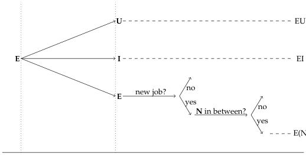

**text found inside the figure**

**E**

**E**

**I** EI

**U** EU

new job? no

yes

**N** in between? no

yes

E(N)E

typically followed by a fall in wealth, while gaining employment is typically followed by a rise

in wealth, which mirrors our finding that workers making *EN* transitions suffer dramatic and

persistent wealth declines. Larkin (2019) documents that workers with higher *EU* risk have

more liquid portfolios. This is in principle not in conflict with our finding that workers with

higher *EU* risk have lower wealth in the left hand side of the U, both due to our flexible empir-

ical specification picking up non-monotone effects and because we focus on total wealth and

not portfolio composition. We contribute to these papers by documenting a novel U-shaped

pattern, and developing a theory which can address both sides of this pattern.

Many of the above papers additionally develop rich theoretical models that can explain

the relationships found in the data. A joint theoretical literature also exists which combines

labour market models and incomplete markets. Papers which deal more with the aggregate or

business cycle effects of these interactions include Acemoglu and Shimer (1999), Krusell et al.

(2010), Ravn and Sterk (2017), den Haan et al. (2018), and Ravn and Sterk (2021). Herkenhoff

(2019) and Braxton et al. (2020) study the effect of credit access on non-employed search de-

cisions, and Lentz and Tranæs (2005) look at how wealth can explain duration dependence in

*UE* rates. Eeckhout and Sepahsalari (2021) demonstrate how wealth affects the allocation of

workers to jobs of differing productivities, and Huang and Qiu (2021) the mismatch between

firm and worker types. Finally, Hubmer (2018) develops a rich job ladder model that includes

incomplete markets, and Chaumont and Shi (2022) build a job ladder model with directed

search where lower wealth agents have higher job to job transition rates, in line with the data.

The rest of the paper is structured as follows. Section 2 presents the data, and Section 3 our

empirical results. Our quantitative model and results are given in Section 4, and in Section 5

we conclude.

### **2 Data**

Our data is taken from the Panel Study of Income Dynamics (PSID), a longitudinal study of

households in the United States. The survey ran annually from 1968, interviewing around

9000 families before switching to biannual surveys from 1997 until present. The PSID con-

5

Page 6

tains detailed questions on a number of social issues and importantly for our purposes, there

is detailed data on labour market status and household wealth.<sup>5</sup> Due to the availability of

the wealth data and other continuities in the data such as consistency in the variables that de-

scribe individual histories in the labour market, which we use to construct transitions between

employment and non-employment, our core estimation sample is limited to 1999-2017. How-

ever the waves prior to 1999 are used to construct tenure and transition variables whenever

necessary.

We limit our sample to individuals between the ages of 18 and 65 from the core PSID sample

dropping those who are from the immigrant sample and the Survey to Economic Opportunity

sample. We include only individuals who are consistently the household reference person or

spouse whilst in the sample, and include both men and women. We only include individuals

once they join the labour market, and only include them until the point they permanently leave

the labour market.<sup>6</sup> We further restrict to those who do not experience self employment nor

government employment, and are not employed in farming, mining or public administration

industries. We also drop observations with a real hourly wage less than 1 dollar. All of those

restrictions are standard and have been employed in earlier work. Given our interest in tran-

sitions out of employment, we further require that we observe an individual for at least two

consecutive waves of the survey after implementing all the other sample restrictions. We end

up with a panel containing 27,832 observations on 5,151 individuals. We have on average 5.4

observation per individual in the data.

Our main dependent variable is whether an individual has made *at least one* transition from

employment to non-employment between survey waves. To measure whether a worker has

transitioned between employment and non-employment between consecutive waves in years

*t* and *t* + 2 we use information from both waves, and create a binary variable *ENi*,*t*. To be

recorded as having made an *EN* transition (*ENi*,*t* = 1), the worker must satisfy the following

conditions. Firstly, the worker should report being in employment (E) in wave *t*. Next, we

check the worker’s labour market status in year *t* + 2. If they report being either unemployed

(U) or inactive (I), we set *ENi*,*t* = 1. If, however, they report being employed in year *t* + 2 and

the information on their tenure suggests they switched employers between interviews, we look

into questions asking they spent any time in unemployment or inactivity between years *t* and

*t* + 2. If the workers report a spell of non-employment, we set *ENi*,*t* = 1 as well. Otherwise,

we set *ENi*,*t* = 0.

Therefore, there are three distinct types of transitions out of employment in year *t* which

are induced by reported labour market histories that we lump into our *ENi*,*t* variable: to

unemployment, *EU*, to inactivity, *EI*, and to employment with an intermittent spell of non-

employment, *E(N)E*. We illustrate this procedure on Figure 1.

5Many other papers relied on PSID data and used information on wealth and/or labour market transitions from this survey. A non-exhaustive list includes Kambourov and Manovskii (2009), Kaplan, Violante, and Weidner (2014), Cortes (2016) and Griffy (2021).

6For example, an individual who was a student when they joined the survey would not be included in our sample until they become active in the labour market reporting either being employed or unemployed. We assume a worker permanently abandons the labour market if they do not report being either employment or unemployment from a given wave onwards.

6

Page 7

Table 1: Labour Market Status and Flows

[output not shown]

*Note:* The sample contains 27,832 observations on 5,151 individuals. The sample includes

individuals aged 18 to 65, who are only added to the sample once they join the labour market. They are then dropped from the sample once they leave the labour market and they do not appear again as employed. We restrict our sample to the core PSID sample who are not self-employed or working for the government or in farming related occupations. Lastly, our sample includes individuals which we observe for at least two consecutive waves.

We present the summary of labour market status and flows in our sample in Table 1. Ap-

proximately 9% of the sample is in non-employment at the interview date. A quarter of work-

ers will make a transition out of current-wave employment and a bit more than half of those

are *EN* transitions. The majority of *EN* transitions are of the *E*(*N*)*E* type.<sup>7</sup>

The key independent variable will be the position of the household in the wealth distribu-

tion. To measure this, we use two wealth variables from the survey, *Net Wealth without Home*

*Equity* and *Net Wealth with Home Equity*. These are calculated and reported in the survey based

on more detailed questions about assets and liabilities at the household level. Home equity is

harder to tap into than, say, cash or stocks, therefore the first wealth variable proxies for the

liquid part of net wealth. As mentioned earlier, we are keeping the household heads and their

spouses, if present, in the sample. While this increases the explanatory power of the data, it

also induces a complication in comparing household wealth between singles and couples. To

address that, we assume an equal split of household wealth between couples.<sup>8</sup> We present

descriptive statistics of the net wealth variables in Table 2. Both measures of net wealth and

their growth feature strong right-skew and large dispersion.

We are also interested in a standard set of demographic characteristics to be used as ad-

ditional controls in our regressions. To this end, we keep information on gender, age, marital

status, number of children, ethnicity, and educational attainment in the data. Furthermore,

we also include industry and occupation controls, where these are measured using aggregated

census industry and occupation codes to the 2 digit level. Last, but not least, we collect infor-

mation on hourly wage at the main job at time of interview. We report descriptive statistics of

our sample in Table A.1. All monetary variables are expressed in 2015 US dollars.

7We discuss further details of the construction of the *ENi*,*t* variable and robustness of our main result to an alternative approach in Online Appendix B.1.1.

8One can imagine ranking individuals in the sample differently, e.g., based on the distribution of household wealth or constraining the sample only to household heads. We offer more discussion of this and robustness checks in the Online Appendix B.1.2 and B.1.3, respectively.

7

Page 8

Table 2: Distribution of Per-Capita Net Wealth and its Accumulation

[output not shown]

*Note:* All values expressed in thousands of 2015 US dollars. The sample contains 27,832 observations

on 5,151 individuals. The sample includes individuals aged 18 to 65, who are only added to the sample once they join the labour market. They are then dropped from the sample once they leave the labour market and they do not appear again as employed. We restrict our sample to the core PSID sample who are not self-employed or working for the government or in farming related occupations. Lastly, our sample includes individuals which we observe for at least two consecutive waves.

### **3 Empirical Results**

In this section, we empirically investigate the relationship between wealth and *EN* transitions

using the PSID data. We find that this relationship is U-shaped and is robust to a battery

of checks. Then, we document that *EN* transitions have sizeably negative, persistent, and

statistically significant effects on wealth accumulation.

#### **3.1 Estimation Strategy**

Our starting point is the following linear probability (LPM) model specification:

*δt* +

**equation / math rendering (image)**

### *D* ∑ *d*=1

*δdW<sup>d</sup>*

*i*,*t* <sup>+</sup>*<sup>X</sup><sup>′</sup>*

This regression estimates the determinants of the probability of observing an *EN* switch for

individual, *i* between time *t* and *t* + 2, coded as the binary variable *ENi*,*t*. We partition the

wealth distribution into *D* ranked bins, *d ∈{*1, ..., *D}* and the main variable of interest is the

time-*t* per-capita wealth, *Wealthi*,*t*, where we use either liquid or total net wealth. We employ

indicator functions equal to one if *Wealthi*,*t* belongs to bin *d* of the wealth distribution which

we denote *W<sup>d</sup>*

*i*,*t*<sup>.</sup> <sup>The coefficients</sup>*<sup>δ</sup><sup>d</sup>* <sup>capture the effect of belonging to wealth bin</sup>*<sup>d</sup>*<sup>on the prob-</sup>

ability of making an *EN* switch. As our sample spans both booms and busts, we control for

business cycle fluctuations with time dummies *δt*. We include additional controls in the re-

gression in order to control for standard observables. This is important for identifying the true

effect of wealth on *EN* transition, as wealth might be correlated with other observables, such

as wages or age, which also affect the probability of making such a transition. Other controls

8

Page 9

Figure 2: Margins of Deciles of wealth on the probability of an *EN*-transition (LPM).

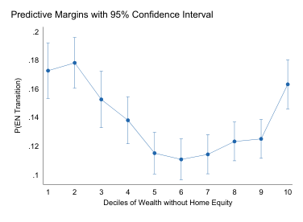

**text found inside the figure**

.1

.12

.14

.16

.18

.2

P(EN Transition)

1 2 3 4 5 6 7 8 9 10 Deciles of Wealth without Home Equity

Predictive Margins with 95% Confidence Interval

(a) Liquid Net Wealth

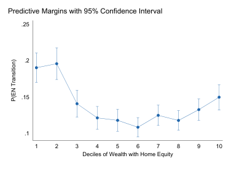

**text found inside the figure**

.1

.15

.2

.25

P(EN Transition)

1 2 3 4 5 6 7 8 9 10 Deciles of Wealth with Home Equity

Predictive Margins with 95% Confidence Interval

(b) Total Net Wealth

*Note:* These figures plot the predictive margins on deciles of wealth from a linear probability model regression as presented in equation 1. Panel 2a includes deciles of wealth without home equity, whilst Panel 2b includes deciles of wealth with home equity. Year fixed effects, individual controls and a full set of industry and occupation controls are included. Standard errors are clustered at the individual level. Data is from waves 1999-2017 of the PSID.

are summarised in *Xi*,*t*, with vector of *X* controls for individual *i* in time *t*. The additional

covariates include: gender, race, years of completed schooling, whether the individual is mar-

ried, and their number of children. We further control for a cubic polynomial of age, region,

and for log hourly wage. Standard errors are clustered at the individual level.<sup>9</sup>

#### **3.2** *EN* **Transitions as a Function of Wealth**

To begin with, we estimate (1) splitting the wealth distribution into deciles. We then plot the

marginal effects of being in a given wealth decile in Figure 2. Panel (a) represents the results

using liquid wealth, and Panel (b) is for total wealth. Regardless of the measure of wealth used,

we observe a rough U-shape in the probability of an *EN* transition, with the workers in the top

10% of the household wealth distribution having a higher likelihood of an *EN* transition than

those in the median-to-90-th-percentile part of the distribution. Lower wealth individuals,

particularly those in the bottom two deciles, also have a higher likelihood of experiencing an

*EN* transition. Indeed, those workers actually have the highest *EN* rates across both measures

of wealth. This U-shaped relationship is, to the best of our knowledge, novel, and represents

the key empirical contribution of our paper.<sup>10</sup>

The figures give 95% confidence bands, showing that the results are quite precisely es-

timated and suggesting statistically significantly different *EN* rates across the wealth distri-

bution. The results are also quantitatively significant. Workers in the middle of the wealth

distribution typically have a 12% probability of reporting an *EN* transition in the two years

between sample waves. For workers in the bottom wealth decile this is closer to 17%, meaning

9The estimated coefficients for the LPM specification are qualitatively and quantitatively similar to the marginal treatment effects obtained from logit and probit regressions, see Online Appendix B.1.4.

10We show that the relationship between wealth and *EN* transitions is substantially different from how wealth impacts on transitions from employment to employment and from non-employment to employment in Online Appendix B.2.

9

Page 10

Table 3: Focusing on the Tails of the Wealth Distribution.

[output not shown]

* p *<* 0.1, ** p *<* 0.05, *** p *<* 0.01. Standard errors in parentheses.

*Note:* Standard errors are clustered at the individual level. Low Wealth and High

Wealth correspond to the bottom and the top decile of respective wealth distribution. Base group is the remainder of the wealth distribution. Individual controls include age, education, female, race, marital status, number of children, hourly wage, and region. Industry and occupation dummies are based on 2- digit classifications.

a bit less than 50% increase in their *EN* rate. Similarly, for workers in the top wealth decile

Secondly, to perform a sharp test of the statistical differences across wealth distributions,

and to allow easy comparison of results across specifications and motivated by evidence re-

ported in Figure 2, we split the wealth distribution into three bins, the bottom 10%, middle

80% and top 10%. For the remainder of the paper we therefore focus on the following spe-

cialised version of equation (1):

*Pr*(*ENi*,*t|Wealthi*,*t*,*Xi*,*t*) = *α* + *δ*1*W*<sup>1</sup>

*i*,*t* <sup>+</sup>*<sup>δ</sup>*<sup>10</sup>*<sup>W</sup>*<sup>10</sup>

*i*,*t* <sup>+</sup>*<sup>X</sup><sup>′</sup>*

*i*,*t<sup>β</sup>*<sup>+</sup>

### *T* ∑ *t*=1

*δt* + *εi*,*t*. (2)

The dummies *δ*1 and *δ*10 capture the relative difference in the propensity to experience an *EN*

transition by workers in the tails of the wealth distribution relative to the middle group. Find-

ing that both *δ*1 and *δ*10 are statistically significantly greater than zero will therefore constitute

evidence in favour of the U-shaped pattern. We refer to these dummies as *Low Wealth* and *High*

*Wealth* from now on.<sup>11</sup>

11Alternatively, one could specify the dummies differently. In particular, Figure 2 suggests that the *Low Wealth* dummy could be defined to include bottom two deciles of the wealth distribution. We explore this possibility in Online Appendix B.1.5.

10

Page 11

Table 4: *EN* Transitions and Wealth Accumulation

[output not shown]

* p *<* 0.1, ** p *<* 0.05, *** p *<* 0.01. Standard errors in parentheses.

*Note:* Robust standard errors. Individual controls include age, education, female,

race, marital status, number of children, hourly wage, and region. Industry and occupation dummies are based on 2-digit classifications.

We present the results of estimating Equation (2) in Table 3 which shows the estimated co-

efficients for *Low Wealth* and *High Wealth* across both wealth measures and considering various

combinations of controls. The results are fairly similar for liquid and total wealth, and so we

focus on liquid wealth in columns 1 to 3, with results for total wealth given in columns 4 - 6.

For liquid wealth, our preferred specification is in column 3, which includes both individ-

ual controls and controls for the industry and occupation of the individual’s current job. We

find a statistically and economically significant U-shape in the *EN*-wealth relationship. Both

the bottom and top 10% of the wealth distribution have similarly higher probabilities of an

*EN*-switch compared to the middle of the distribution: by 4 p.p. and 3.7 p.p. higher, respec-

tively. These estimates agree closely with the differences in *EN* rates across the whole wealth

distribution shown in Figure 2. In columns 2 and 1 we gradually remove controls to iden-

tify the biases that would be introduced if they had been excluded. Column 2 shows that the

results are very similar excluding the industry and occupation controls, suggesting that the

driving force of the U shape pattern are not the high-level characteristics of the individual’s

work which could be correlated with their industry and occupation.

In column 1 we do not consider any additional controls apart from year fixed effects,

so these numbers simply reflect the correlations between wealth and probability of an *EN*

switch controlling for business cycle fluctuations. Strikingly, we do not observe the U-shape

in propensity to switch, and instead find a purely downwards sloping relationship. Thus the

fact that low wealth agents are more likely to make *EN* switches is visible even when exclud-

ing controls, with the coefficient shrinking, but remaining economically large, when including

controls. On the other hand, the right side of the U shape — the fact that the workers in the

top wealth decile are also more likely to switch — is only visible when including controls, as

the coefficient goes from negative to positive between columns 1 and 3. This is likely because

11

Page 12

wealth is positively correlated with variables such as wage and age which might predict a

lower probability of making an *EN* switch.

#### **3.3 Consequences of** *EN* **Transitions**

Next, we look at the consequences of *EN* transitions for wealth accumulation. We estimate

Equation (3) where the dependent variable is the change in individual net wealth *k* years from

current interview date (in thousands of US dollars in 2015). Apart from using the full set of

controls we also add the *ENi*,*t* dummy. To avoid the effects of extreme outliers present in the

data, we estimate a quantile regression, taking the median as the targeted moment.

*Wi*,*t*+*k −Wi*,*t* = *α* + *X<sup>′</sup>*

*i*,*t<sup>β</sup>*<sup>+</sup>

### *T* ∑ *t*=1

*δt* + 1*ENi*,*t* + *εi*,*t* (3)

The main result of this exercise, which we report in Table 4, is that there are persistent,

significant and negative effects of *EN* transitions on growth of per-capita wealth. Relating the

estimated coefficients from Table 4 to median per-capita wealth accumulation in Table 2, we

find that the immediate effect of *EN* is a bit less than a half of median net wealth growth in 2

year time. This effect then shrinks slightly to approximately 40% over six years. As far as net

wealth with home equity is concerned, the immediate effect is approximately one quarter of

median wealth accumulation which then increases mildly to about 30% over six years.

#### **3.4 Robustness Checks**

We have subjected our novel result on the U-shaped relationship between *EN* transitions and

net per-capita wealth to a battery of tests. We provide details of their results in the Appendices

and give a brief overview here.

Firstly, we test if our result is driven by composition effects that are specific to demographic

characteristics of primary importance: gender (e.g., because of women being more risk averse

than men), family composition (e.g., couples and singles search behaviour differing) and edu-

cation (e.g., because of inherent differences in riskiness of jobs specific to education). Results

presented in Table A.2 demonstrate that this is not the case. The point estimates of *Low Wealth*

and *High Wealth* coefficients are positive and significant in all but one specification.

Secondly, we investigate the robustness of our result to life-cycle effects. Again, our re-

sult is robust, see Table A.3, which demonstrates that the U-shape prevails well into mid-age.

That the U-shape is present among the youngest workers emphasizes that our results are not

driven via spurious correlations from other variables correlated with wealth. The wealth ob-

served for younger individuals is more likely to be family wealth, rather than wealth they have

personally accumulated over time from employment. Hence, the finding that wealth affects

*EN* transitions for younger people is even less likely to be by correlations between wealth and

other variables such as wages or unobserved differences in *EN* risk.

Thirdly, we also checked for potential reverse causality. One could argue that particularly

the left side of the U-shape could be due to some workers being permanently exposed to higher

non-employment risk which would then impede their accumulation of wealth. In that case,

12

Page 13

non-employment would cause low wealth, not the other way round. As can be seen in Table

A.4, this is not the case.

### **4 Quantitative Model**

In the remainder of the paper we present a heterogeneous agent model of incomplete markets

with a frictional labour market where workers face heterogeneous separation risks. The model

builds on the incomplete markets models of Bewley (1983), Imrohoro˘glu (1989), Huggett (1993),

and Aiyagari (1994).

#### **4.1 Description of the model**

The model is in continuous time, and is populated by a unit mass continuum of ex-ante iden-

tical workers. We focus purely on the worker side of the market, making this a partial equi-

librium model where the distribution of job opportunities is exogenous. We suppress the time

index, *t*, and worker index, *i ∈*[0, 1], where it does not cause confusion.

Workers are infinitely lived and discount future at rate *ρ >* 0. They are risk averse, with

preferences over the consumption flow, *ct*, described by a utility function *u*(*ct*) with *u<sup>′</sup>*(*ct*) *>* 0,

*u<sup>′′</sup>*(*ct*) *<* 0. Workers can be either employed or non-employed (inactive), where we discuss the

distinction between unemployment and inactivity below. Working entails a fixed utility cost

*f >* 0, which is not incurred when non-employed.

Workers can borrow and save only using a risk free bond with interest rate *r*. We denote a

worker’s assets with *at* and impose the borrowing constraint *at ≥a*. Given current income *yt*,

which can be either wages or non-employment income, assets evolve according to

˙*at* = *yt* + *rat −ct* (4)

Since the consumption flow must be finite, assets will never jump in this model (*−*∞*<* ˙*a <*

∞). This means that the borrowing constraint *at ≥a* will never become binding in the next

instant of time whenever *at > a*. Therefore, the borrowing constraint only places constraints

on decision making when *at* = *a*, at which point consumption must satisfy ˙*at ≥*0 =*⇒ct ≤*

*yt* + *ra*. The fear of hitting this borrowing constraint means that lower wealth agents become

effectively more risk averse.

When non-employed, workers receive benefits *b* as income. This could alternatively be

interpreted as home production. This is received regardless of whether a worker actively

searches for a job or not, and so we do not distinguish between unemployment and inac-

tivity in the model, for example by assuming that the government cannot observe search ef-

fort. While non-employed, workers search for a job. All jobs pay the same constant wage,

*w*, where we abstract from wage differences because our empirical work identified that all of

our findings held even controlling for wages. We thus consider our model as distinguishing

the behaviour of different workers within the same broad wage level (for example, within a

group with the same educational attainment) but with different levels of assets due to their

idiosyncratic employment histories.

13

Page 14

There are two types of jobs in the economy, distinguished by their level of risk. “Risky” jobs

are destroyed, returning the worker to unemployment, at rate *δh*. “Safe” jobs are destroyed

at the lower rate *δl < δh*. We abstract from on the job search, and so only non-employed

workers search for jobs.<sup>12</sup> We assume that the risky job is easier to find than the safe job, which

motivates why workers might search for the risky job despite it being otherwise dominated by

the safe job. As we will discuss, this assumption is also consistent with the existing evidence

(e.g. Herkenhoff et al., 2016) that job finding rates are higher for low wealth workers.

Specifically, we assume that non-employed workers must direct their search to either the

risky or safe job at any given moment in time. Search is costless and search effort is fixed.

If an non-employed worker chooses to search for a risky job, they will receive a job offer at

rate *λ*(*δh*). If they choose to search for a safe job it will arrive at the slower rate *λ*(*δl*) *<*

*λ*(*δh*). If an non-employed worker would prefer to remain non-employed because the value of

unemployment dominates the value of both jobs, they may also choose not to search for a job.

Similarly, if an employed worker would prefer to be non-employed and quit, we allow them

to do so.

#### **4.2 Worker value and policy functions**

The above model structure implies the following value functions for workers, expressed as

Hamilton-Jacobi-Bellman equations. Define *v<sup>u</sup>*(*a*) as the value of being non-employed with

current wealth *a*. This is given by:

subject to *c ≤b* + *ra* when *a* = *a*. The first and second terms on the right hand side describe

the utility from consumption and the drift in value from the implied change in assets. The final

term describes the change in value if a worker becomes employed, given the risk *δ* of the job

they search for and its arrival rate *λ*(*δ*).

Define *v<sup>e</sup>*(*a*, *δ*) as the value of being employed with assets *a* at a job with risk *δ*. This is

given by:

*ρv<sup>e</sup>*(*a*, *δ*) = max

+ *ζ*(max*{v<sup>e</sup>*(*a*, *δ*), *v<sup>u</sup>*(*a*)*} −v<sup>e</sup>*(*a*, *δ*)) (6)

Relative to an non-employed worker, notice that an employed worker pays the utility flow

cost *f*, and has income *w*. The term *δ*(*v<sup>u</sup>*(*a*) *−v<sup>e</sup>*(*a*, *δ*)) captures the probability of a layoff and

returning to unemployment. Finally, to allow workers to quit from employment in a tractable

way, we assume that workers may not instantaneously quit, but receive the opportunity to

quit at rate *ζ*. If *v<sup>e</sup>*(*a*, *δ*) *< v<sup>u</sup>*(*a*), they will then do so, and transition to unemployment. We

12Given that we abstract from wage differences, on the job search in our model would only be between levels of risk, with workers in high risk jobs searching to move up the safety ladder to a low risk job. While this is an interesting feature, in the data job-to-job moves are also driven by workers moving to higher wage jobs, and so calibrating a realistic degree (e.g. 2% monthly rate) of on the job search in a model without wage differences would overstate the degree to which workers perform on the job to move up the safety ladder.

14

Page 15

interpret this rate as the fact that workers must give notice before quitting, for example having

to work for a final month.<sup>13</sup>

The solution to the consumption-saving problem for all workers is standard. For employed

workers with *a > a* the first order condition gives *u<sup>′</sup>*(*c*) = *v<sup>e</sup>*

*a*<sup>,</sup> <sup>and</sup> <sup>similarly</sup> <sup>so</sup> <sup>for</sup> <sup>non-</sup>

employed agents. Workers with *a* = *a* may be constrained to set a lower value of consumption

by the borrowing constraint. More important for our analysis are the worker’s labour mar-

ket decisions, which we discuss in more detail along with our results. In brief, we will find

that low wealth non-employed workers will search for risky jobs, and high wealth employed

workers will choose to quit to non-employment, both of which are important for matching the

*U*-shape in the data.

#### **4.3 Illustrative Calibration**

We calibrate our model to match standard labour market facts, as well as our new empirical

results. The calibration is monthly, so that one unit of time equals one month. We set the

discount rate *ρ* to give a 5% yearly rate, and the risk free rate *r* to a 2% yearly rate.

We normalise the wage to *w* = 1 and set *b* = 0.4 to give a 40% replacement rate. We

specialise to a CRRA utility function *u*(*c*) = *c*<sup>1</sup>*<sup>−</sup><sup>σ</sup>*/(1 *−σ*) and set a relatively high value of

risk aversion of *σ* = 4. We set the borrowing constraint to *a* = *−w* to allow borrowing of up

to one month’s wage. We set the notice period for employed workers to quit to *ζ* = 1, so that

workers receive the opportunity to quit once a month on average, in line with a one month

notice period.

Moving on to the labour market moments, we set the parameters of the safe job to match

standard labour market moments. We compute the EN rate in the model by averaging across

all EN transitions from safe jobs, risky jobs, and quits to unemployment, and match an average

monthly EN rate of 3%. We target this number by adjusting the separation rate in the safe job,

*δl*. We target a 6% unemployment rate, which we achieve by adjusting the job finding rate of

the safe job, *λ*(*δl*).

We set the parameters of the risky job and the cost of working to match our new fact that

the *EN*-wealth relationship is *U*-shaped. The results in Figure 2(a) show that the ratio of the

EN rate in the bottom decile (0-10%) of the wealth distribution to the rate in the fifth decile (40-

the risky job in equilibrium, we choose *δh* to match this same fact in our model, by raising the

separation rate of the risky job. We set the arrival rate of the risky job, *λ*(*δh*) to match the ratio

the data. By controlling the relative attractiveness of searching for the risky job, this controls

at which wealth level wealth-poor agents will flip from searching for the risky job to searching

for the safe job, and hence how far up the wealth distribution high EN risk remains elevated.

13This structure is computationally helpful, as it allows us to model notice periods in a recursive way. Additionally, by ruling out that workers can instantaneously quit, we avoid having to specify the problem as a Linear Complementarity Problem, allowing us to use fast, standard methods to solve the value function. As *ζ →*∞the solution approaches the solution where workers can instantly quit, and in practice the results are very similar even with *ζ* = 1.

15

Page 16

Table 5: Quantitative Model: Calibration

[output not shown]

*Note:* Parameter values and target moments. See the text for details of our calibration strategy.

Similarly, the results in Figure 2(a) show that the ratio of the EN rate in the top decile of the

Since high wealth individuals will quit to unemployment, driving a high EN rate via quits, we

choose *f* to match this same fact in our model, by changing the utility cost of working. We

calculate both of these ratios using the monthly separation rates at each wealth decile in our

model.

**Discussion of identified parameter values** Our target moments and identified parameter

values are given in Table 5. The estimation finds that reasonable values for these parameters

are required to hit the moments. The safe job has a separation rate of 1.9% per month, and a

job offer arrival rate of 38% per month. The risky job has a separation rate nearly two times

higher, at 4.1% per month, but a faster job offer arrival rate of 55%. This implies an average

wait time of 2.6 months for a safe job and only 1.8 months for a risky job.

Finally, the disutility of work parameter can be interpreted as follows. The hypothetical

flow utility gap between consuming the wage *w* and benefits *b* is *u*(*w*) *−u*(*b*) = 4.875. So

the flow disutility of working *f* = 0.6462 is equal to 13% of this consumption value. We thus

identify a relatively small cost of working, which is sufficient to drive quits towards the top

end of the wealth distribution.

#### **4.4 Result 1: “U shaped”** *EN***-wealth relationship**

The first result from our quantitative model is that we are able to successfully reproduce the U

shaped *EN*-wealth relationship that we found in the data. This is shown in Figure 3(a), where

we plot the EN rate by wealth decile in our estimated model. We replicate well the data from

Figure 2, in particular: i) the U shaped pattern, ii) the relative EN rates at the top and bottom

10% of the distribution, and iii) the gradual reduction in EN rates by wealth as wealth increases

16

Page 17

Figure 3: EU Rate and Polcy: Model

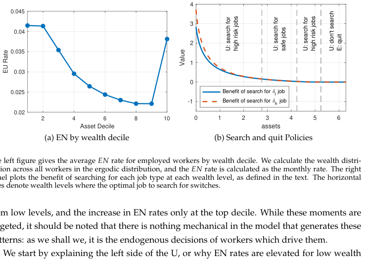

**text found inside the figure**

2 4 6 8 10 Asset Decile

0.02

0.025

0.03

0.035

0.04

0.045

EU Rate

(a) EN by wealth decile

0 1 2 3 4 5 6 assets

-1

0

1

2

3

Value

U: search for

high risk jobs

U: search for

safe jobs

U: search for

high risk jobs

U: don't search

E: quit

Benefit of search for /l job

Benefit of search for /h job

(b) Search and quit Policies

The left figure gives the average *EN* rate for employed workers by wealth decile. We calculate the wealth distribution across all workers in the ergodic distribution, and the *EN* rate is calculated as the monthly rate. The right panel plots the benefit of searching for each job type at each wealth level, as defined in the text. The horizontal lines denote wealth levels where the optimal job to search for switches.

from low levels, and the increase in EN rates only at the top decile. While these moments are

targeted, it should be noted that there is nothing mechanical in the model that generates these

patterns: as we shall we, it is the endogenous decisions of workers which drive them.

We start by explaining the left side of the U, or why EN rates are elevated for low wealth

4

workers. Consider whether an non-employed worker would prefer to search for a risky or safe

*λ*(*δh*)(*v<sup>e</sup>*(*a*, *δh*) *−v<sup>u</sup>*(*a*)) *> λ*(*δl*)(*v<sup>e</sup>*(*a*, *δl*) *−v<sup>u</sup>*(*a*)), (7)

which can be expressed as:

*λ*(*δh*)

**equation / math rendering (image)**

*λ*(*δl*) *<sup>></sup> <sup>v</sup><sup>e</sup>*<sup>(</sup>*<sup>a</sup>*<sup>,</sup>*<sup>δ</sup><sup>l</sup>*<sup>)</sup>*<sup>−</sup><sup>v</sup><sup>u</sup>*<sup>(</sup>*<sup>a</sup>*<sup>)</sup>

*v<sup>e</sup>*(*a*, *δh*) *−v<sup>u</sup>*(*a*)<sup>.</sup> (8)

That is, a worker will choose to search for the risky job if the increase in the speed of receiving

a job offer (*λ*(*δh*)/*λ*(*δl*) *>* 1) compensates for the fact that the higher risk job gives relatively

lower value ((*v<sup>e</sup>*(*a*, *δl*) *−v<sup>u</sup>*(*a*))/(*v<sup>e</sup>*(*a*, *δh*) *−v<sup>u</sup>*(*a*)) *>* 1 since *v<sup>e</sup>*(*a*, *δh*) *< v<sup>e</sup>*(*a*, *δl*)). Without fur-

ther information, it is not possible to say which side is greater and hence which job is preferred.

Indeed, non-employed workers with different asset levels will prefer to search for different

jobs. In Figure 3(b) we plot *λ*(*δh*)(*v<sup>e</sup>*(*a*, *δh*) *−v<sup>u</sup>*(*a*)) and *λ*(*δl*)(*v<sup>e</sup>*(*a*, *δl*) *−v<sup>u</sup>*(*a*)) which we use

to show which job workers prefer searching for at each range of the wealth distribution.

Intuitively, non-employed workers with low wealth are very effectively risk averse, be-

cause they know they will run out of wealth soon. They thus will choose to search for the risky

job, which is quicker to get. Mathematically, this is represented by the fact that *v<sup>u</sup>*(*a*) becomes

very concave in *a* for low values of *a*. Since *v<sup>e</sup>*(*a*, *δh*) *−v<sup>u</sup>*(*a*) is smaller than *v<sup>e</sup>*(*a*, *δl*) *−v<sup>u</sup>*(*a*),

the steep decline in *v<sup>u</sup>*(*a*) as *a* falls leads to a proportionally larger increase in the denomina-

tor, causing the right hand side fraction to fall and pushing agents towards choosing the risky

17

Page 18

Figure 4: Value and Policy Functions

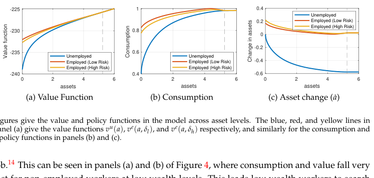

**text found inside the figure**

0 2 4 6 assets

-240

-235

-230

-225

Value function

Unemployed Employed (Low Risk) Employed (High Risk)

(a) Value Function

0 2 4 6 assets

0.4

0.6

0.8

1

Consumption

Unemployed Employed (Low Risk) Employed (High Risk)

(b) Consumption

0 2 4 6 assets

-0.6

-0.4

-0.2

0

0.2

0.4

Change in assets

Unemployed Employed (Low Risk) Employed (High Risk)

(c) Asset change ( ˙*a*)

Figures give the value and policy functions in the model across asset levels. The blue, red, and yellow lines in panel (a) give the value functions *v<sup>u</sup>*(*a*), *v<sup>e</sup>*(*a*, *δl*), and *v<sup>e</sup>*(*a*, *δh*) respectively, and similarly for the consumption and

˙*a* policy functions in panels (b) and (c).

job.<sup>14</sup> This can be seen in panels (a) and (b) of Figure 4, where consumption and value fall very

fast for non-employed workers at low wealth levels. This leads low wealth workers to search

for the risky job before switching to searching for the safe job for intermediate wealth levels,

as shown in Figure 3(b).

Surprisingly, despite saving them only three weeks of expected time in non-employment,

low-wealth workers prefer to search for the risky job, because the consumption drop from

being non-employed at low-wealth is so severe. Notice that this means that our model is also

endogenously consistent with the existing evidence that low wealth agents have higher *UE*

rates, as discussed in the literature review. This justifies our assumption that risky jobs have

higher arrival rates, because the fact that low wealth agents search for these jobs then drives

their higher *UE* rates. The calibrated differences in the arrival rates of the two jobs also appear

in line with estimates of the sensitivity of *UE* rates to wealth and credit.<sup>15</sup> Finally, recall that

we compute the EN-wealth relationship by looking at current wealth, not wealth at the time a

job was taken (as in our empirical work). Since wealth is a persistent state variable the realised

EN rate becomes correlated with current wealth.

Moving on to the right hand side of the U, this is driven by quits in our model, consistent

with the suggestive evidence that quits are also more important at high wealth in the data.

Sufficiently wealthy workers quit to unemployment because working is costly, due to the fixed

cost *f*, and they can afford to finance high consumption in non-employment by running down

their savings. Figure 3(b) shows that workers only quit employment for the highest wealth

levels, above a certain threshold. At this high level of wealth, the drop in consumption from

being non-employed is actually relatively small, as shown in Figure 4(b). Workers who quit

therefore run down their savings in a temporary non-employment spell and begin searching

for a new job as their savings deplete. An interesting side effect of this is that sufficiently

wealthy workers actually start searching for the risky job again above a certain threshold. This

14Since *a* also affects *ve*(*a*, *δh*) and *ve*(*a*, *δl*) proving this analytically is challenging. Our numerical results confirm that this intuition holds at our estimated parameter values.

15For example, Herkenhoff et al. (2016) show that an increase in credit limits of 10% of prior earnings encourages workers to spend 0.15 to 3 weeks longer in unemployment. While the nature of the experiment differs, the order of magnitude of the difference in *UE* rates is the same as the difference between the two rates in our model.

18

Page 19

Figure 5: Model Distributions

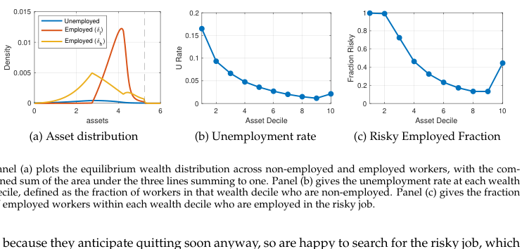

**text found inside the figure**

0 2 4 6 assets

0

0.005

0.01

0.015

Density

Unemployed Employed (/l)

Employed (/h)

(a) Asset distribution

2 4 6 8 10 Asset Decile

0

0.05

0.1

0.15

0.2

U Rate

(b) Unemployment rate

2 4 6 8 10 Asset Decile

0

0.2

0.4

0.6

0.8

1

Fraction Risky

(c) Risky Employed Fraction

Panel (a) plots the equilibrium wealth distribution across non-employed and employed workers, with the combined sum of the area under the three lines summing to one. Panel (b) gives the unemployment rate at each wealth decile, defined as the fraction of workers in that wealth decile who are non-employed. Panel (c) gives the fraction of employed workers within each wealth decile who are employed in the risky job.

is because they anticipate quitting soon anyway, so are happy to search for the risky job, which

they intend to quit anyway, and benefit from the increased *NE* rate.

#### **4.5 Result 2: Effect of** *EN* **switch on future wealth**

In Section 3.3 we showed that making an EN switch leads to a significant and long lasting

decline in future wealth in the data. Intuitively, workers are forced to run down their savings

after losing their job in order to finance their consumption without a job. Our model naturally

generates this fact, as shown in Figure 4(c). We see that the optimal asset accumulation policy

has ˙*a <* 0 for non-employed agents at all wealth levels. After losing their job, workers run

down their assets gradually in order to sustain consumption while only receiving benefits,

and gradually reduce their consumption as their assets fall. Eventually, if they are unlucky

enough to remain non-employed for long enough they will deplete their assets all the way to

the borrowing limit *a*.

Thus, the model generates a feedback loop between wealth and non-employment risk, as

in the data: Low wealth leads workers to select into higher unemployment risk jobs, but losing

these jobs then leads to lower wealth, and so on. This is a market failure in the model due

to incomplete insurance markets: agents would like to be able to insure away idiosyncratic

unemployment risk, but cannot. This leads to inefficient consumption and wealth inequality

and hence losses in welfare.

Figure 4(c) also shows that employed agents have ˙*a >* 0 and so accumulate assets for

two reasons. Firstly, they accumulate assets as precautionary savings against becoming non-

employed via the involuntary separation shock. Since unemployment risk is higher in the

risky job, workers have higher ˙*a* at each wealth level in the risky job than the safe job. Secondly,

workers accumulate assets in order to finance their voluntary quits to unemployment, so they

can spend some time not paying the cost of working. Since agents in our model are infinitely

lived they thus follow cycles of asset accumulation and depletion: In unemployment they run

down their assets, and while employed they build them up again.

Notice that this process is doubly painful for low wealth agents, whose consumption is

depressed for two reasons. Firstly, their consumption is depressed each time they become

19

Page 20

Figure 6: Distributions: Full model vs. Aiyagari-type model

-1 0 1 2 3 4 5 6 assets

0

0.1

0.2

0.3

0.4

0.5

density

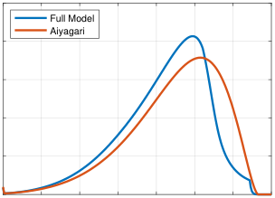

**text found inside the figure**

Full Model Aiyagari

non-employed. Secondly, they select into risky jobs and must therefoe keep their consumption

lower than those in safe jobs in order to finance precautionary savings against future job loss.

Finally, in Figure 5 we plot the equilibrium asset distribution in the model, as well as the

unemployment rate and fraction of employed workers in risky jobs at each wealth decile.

#### **4.6 Result 3: Implications of Endogenous Risk for Distribution of Wealth**

We will now show that the structure of risk and its correlation with wealth matter for precau-

tionary savings models. To do this, we solve a pure Aiyagari version of our model with two

exogenous income states *w* and *b* with transition matrix given by the same overall average

*EN* and *NE* rates as in our model. The disutility of work *f* is set to zero and there is no job-

risk choice by construction. We keep all other parameters e.g., risk aversion *σ* and the interest

rate *r*, unchanged. This *benchmark Aiyagari* model has the same observable *EN* and *NE* rates.

However, there are significant differences between the two models in incentives to accumulate

wealth, wealth distribution, and the importance of the precautionary savings motive.

To show this, we plot the wealth distribution in our model and the Aiyagari model in

Figure 6. Since the interest rate has not been adjusted and the incentives to accumulate wealth

are different, this leads to a different amount of aggregate wealth in equilibrium in each model.

In the benchmark Aiyagari model the agents want to accumulate more wealth than our model,

especially at the higher wealth levels. This is because there is more demand for precautionary

saving in the benchmark model as all agents face the same EN rate of 3% per month and NE

rate of 47% per month.

In our model, workers in safe jobs face lower exogenous job destruction rate of 2% and

hence have lower precautionary savings motive. At the same time, these workers make it to

the top of the wealth distribution more often as they have more time to save in employment

than agents in risky jobs. The workers in risky jobs have a higher precautionary saving motive

but they also lose their jobs more often and as a result of that cannot accumulate much more

wealth. These differences in exposure to risk and the ability of agents to save their way away

20

Page 21

Figure 7: Simulating non-employed workers with different starting wealth

[figure not shown]

**text found inside the figure**

-1 0 1 2 3 4 5 6 assets

0

0.5

1

1.5

2

2.5

density

1 month 1 year 2 years 3 years 5 years ergodic

(a) At borrowing constraint

-1 0 1 2 3 4 5 6 assets

0

0.5

1

1.5

2

2.5

density

1 month 1 year 2 years 3 years 5 years ergodic

(b) At modal wealth

-1 0 1 2 3 4 5 6 assets

0

0.5

1

1.5

2

2.5

density

1 month 1 year 2 years 3 years 5 years ergodic

(c) At maximum wealth

from the borrowing constraint shape how much precautionary savings there is in the aggre-

gate. Because of these differences, the aggregate wealth is 3.20 in our model and 3.49 in the

benchmark Aiyagari model implying a 9% difference in aggregate precautionary savings.

Another way of saying this is to recalibrate the interest rate *r* to keep the same amount of

aggregate wealth. *r* is 2% annually in our calibration, and to keep the same amount of wealth

in the Aiyagari model requires *r* to be 1.44% annually. This 25% decline in the interest rate

is needed to discourage wealth accumulation to keep aggregate wealth the same in the two

models, and shows just how important the structure of risk is in these models.

#### **4.7 Result 4: Persistence of Wealth**

Next, we take a unit mass of non-employed workers all with some initial wealth *a*0 and simu-

late their experiences going forward over time. Their wealth distribution evolves as they gain

and lose jobs, and eventually converges to the overall ergodic distribution. However, the con-

vergence is slow and shows that one’s current wealth has an important effect on one’s future.

We do this for three wealth levels: at the borrowing constraint, the mode of the wealth distri-

bution, and the wealth level at which workers start wanting to quit. The wealth distribution

are plotted in Figure 7. Even 3 years after the start of the simulation the wealth distribution of

the non-employed who start at the borrowing constraint is still significantly to the left of the

full ergodic distribution.

Part of the reason that the position in the wealth distribution is so persistent is that non-

employed workers at different levels of wealth select different types of jobs, and hence have

different employment experiences going forward. To see this, in Figure 8 we plot the fraction

of the workers who are in risky jobs at each time since the start of the simulation, and the

non-employment rate since the simulation. The three lines are now the three different starting

wealths. In panel (a) we can see that the non-employed workers who start at the borrowing

constraint select risky jobs (as we know) so 100% of those who find jobs are in risky jobs. What

is more suprising is just how persistent this is: 100% remain in risky jobs for nearly three years.

It is only from then on that the fraction in risky jobs starts to fall. In the model, 45% are in risky

21

Page 22

Figure 8: Simulating non-employed workers with different starting wealth

[figure not shown]

**text found inside the figure**

0 2 4 6 8 10 time (years)

0

0.2

0.4

0.6

0.8

1 Borr cons Modal wealth Max wealth

(a) Fraction in risky job

0 2 4 6 8 10 time (years)

0

0.05

0.1

0.15

0.2 Borr cons Modal wealth Max wealth

(b) Unemployment rate

jobs in the true ergodic distribution, but after 10 years of simulation the workers starting from

the borrowing constraint still are nearly 60% in the risky job. So wealth is very persistent,

and has very persistent effects on the types of jobs workers select. The workers starting from

job, for reasons discussed, but as their wealth depletes they also quickly return to more normal

distribution of jobs.

This has important effects on the employment experience going forward, as shown in panel

(b). The plot is truncated to make the differences more visible. Notice how the workers starting

from modal wealth quickly find jobs and their unemployment rate drops to 6% which is the

calibrated non-employment rate. But the workers starting with low wealth (blue line) have

a persistently higher non-employment rate for 10 years. The differences in non-employment

rate come from the EU and UE rates of the two jobs: if a worker only ever searches for the

risky job this rate would be 7% and if they ever search for the safe job it would 4.9%. So the

higher non-employment rate of the low wealth workers is because most of them are stuck in

the high risk jobs for a long period of time, and they therefore spend longer time laid off. This

is very different from the Aiyagari model: future income and risk going forward is completely

independent of one’s current wealth in that model, unlike in ours.